# Text Mining

### literature importante

- clean the tweet : https://towardsdatascience.com/text-mining-with-r-gathering-and-cleaning-data-8f8b0d65e67c
- set your twitter API : https://www.infoworld.com/article/3515712/how-to-search-twitter-with-rtweet-and-r.html
- scrapp by hashtag or region or user : https://cran.r-project.org/web/packages/rtweet/vignettes/intro.html

### connect to API twitter

#only run this now if the point 2 is not done yet. twitter log-in (need to register the account in the pop-up windows) name : textmining13 mdp : textmining2020

```r
library(rtweet)
get_token()
```

no need to run the following code if you have already done this part. follow the instruction to link your twitter app with your R CONSOL. Do it only once.

```r
## load rtweet
library(rtweet)

## store api keys (these are fake example values; replace with your own keys)
api_key <- "cFRZi4lsJGD4DxrtLT24za5UH"
api_secret_key <- "iHBlU1fA5WdQ17N3udi8FWg8TlwugXb8e6c34MNRGmKXNJFIQY"

## authenticate via web browser
token <- create_token(
  app = "TextMiningHEC",
  consumer_key = api_key,
  consumer_secret = api_secret_key)

#verify it

#token
```

## Tweet scrcapping

### Get the tweets

We collect the 3000 last tweets from TRUMP, JOE BIDEN, KAMALA HARRIS, MIKE PENCE. the DF has 90 variable. It’s way too much.

Twitter sets a limit of 3200 tweets per request. So we have to do the same operation for each account (@).

```r
#split the scrapping into two part to avoid the limit
#########REPUCLICAN#############################
#we see that MIKE PENCE the vice president of donald trump doesn't tweet. He only retweet. so we scrap manually the Retweet for him
tweet_trump <- get_timelines("realDonaldTrump", n = 3000,
            include_rts = FALSE)

#get the hastag trump
tweet_trump_hashtag <- search_tweets(
  "#Trump", n = 2000, include_rts = FALSE
)

#vice president tweet
tweet_VP <- get_timelines("VP", n = 3000,
            include_rts = TRUE)

#########DEMOCRATE#############################

tweet_BIDEN <- get_timelines("JoeBiden", n = 3000,
            include_rts = FALSE)

#get the hastage biden
tweet_biden_hashtag <- search_tweets(
  "#Biden", n = 2000, include_rts = FALSE
)

#the vice president selected by biden if he is elected
tweet_KAMALA <- get_timelines("KamalaHarris", n = 3000,
            include_rts = FALSE)
```

### explain the data

we will only keep the variable *text*, *created at*, *retweet_count*, *favorite_count* and *display_text_width* in order to do some basics statistics analysis.

| X1 | text | created_at | retweet_count | favorite_count | display_text_width |
| --- | --- | --- | --- | --- | --- |
| 1 | America Im honored that you have chosen me to lead our great country The work ahead of us will be hard but I promise you this I will be a President for all Americans whether you voted for me or not I … | 2020-11-07T16:52:42 | 141909 | 514735 | 257 |
| 2 | We may be opponents but we are not enemies We are Americans | 2020-11-07T04:07:00 | 42013 | 582759 | 65 |
| 3 | We have to remember the purpose of our politics isnt totally unrelenting warfare | 2020-11-07T04:05:00 | 13636 | 246760 | 82 |
| 4 | I know tensions can be high after a tough election like we just had But we need to remain calm Patient And let the process work out as we count all the votes | 2020-11-07T04:02:00 | 15930 | 273846 | 162 |
| 5 | We are going to be the first Democrats to win Arizona in years We are going to be the first Democrats to win Georgia in years And we re built the Blue Wall in the middle of the country that crumbled j… | 2020-11-07T04:00:00 | 17515 | 234720 | 229 |
| 6 | What is becoming clearer each hour is that record numbers of Americans from all races faiths regions chose change over more of the same They have given us a mandate for action on COVID and the economy… | 2020-11-07T03:59:00 | 14770 | 173907 | 249 |
| 7 | The numbers tell us a clear and convincing story We re going to win this race | 2020-11-07T03:53:59 | 43439 | 615787 | 79 |
| 8 | Tune in as I address the nation on the current state of the race | 2020-11-07T03:46:58 | 8756 | 76460 | 89 |
| 9 | Donald Trump is going to court to stop votes from being counted We have assembled the largest election protection effort in history to fight back and need your help Chip in to make sure every vote is … | 2020-11-06T02:00:00 | 20853 | 217986 | 235 |
| 10 | Keep the faith folks | 2020-11-06T01:20:00 | 60546 | 938494 | 22 |

### clean the data

diffult to read so we have to improve the data set. We have to remove a lot of useless information like: - URL - User - some emoji or special character

only keep the text and transform it

#FINALY WE SAVE OUR DATAFRAME

# Statistical analysis of tweets

In this part, we will simply analyze the statistics of each account analyzed. We don’t use any developed text mining tools but only the collected data.

## Daily tweets frequency

We analize all the tweets from the 2020-10-25 to 2020-11-05. We see that Donald Trump is tweeting more than the other candidates. We also notice a strong decrease in the number of tweets at the end of the campaign. Finally, we also notice that the Republican Vice President is discreet.

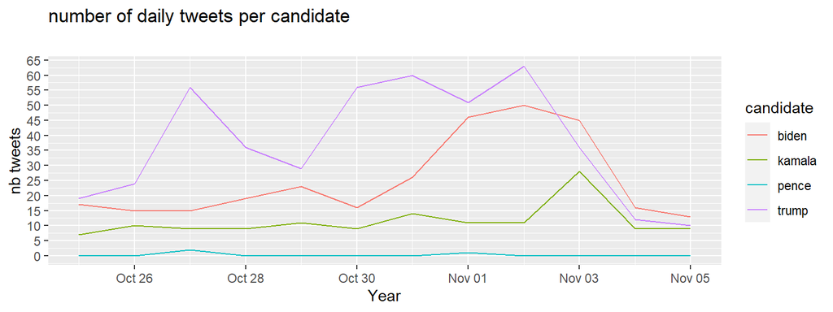

## others statistics

We can also analyze the average number of like or retweet. This shows the power of a candidate on social networks.

The candidate for vice president, Mrs. Harris also uses twitter a lot. For Mike Pence, on the other hand, he only retweets messages. He doesn’t want to put himself forward.

Statistics for @JoeBiden

| nb like | nb retweet | tweet length |
| --- | --- | --- |
| 122131 | 13920 | 147 |

Statistics for @KamalaHarris

| nb like | nb retweet | tweet length |
| --- | --- | --- |
| 66254 | 7370 | 158 |

Statistics for @realDonaldTrump

| nb like | nb retweet | tweet length |
| --- | --- | --- |
| 110655 | 20852 | 129 |

Statistics for @VP

| nb like | nb retweet | tweet length |
| --- | --- | --- |
| 0 | 3829 | 140 |